# Oil Price Volatility and Azerbaijan’s Fiscal Exposure

Rasul Mammadzada

2026-08-30

## Introduction

Oil prices move for reasons that have very little to do with oil. A war, a sanctions decision, or a closed shipping lane can change the price of a barrel by forty percent in a matter of weeks, and no amount of historical data contains any warning that these events are coming. This creates a serious problem for countries whose national budgets depend on oil revenue, because they must plan their spending around a number that nobody can predict. Azerbaijan is one of these countries. Oil and gas dominate its exports, and when Brent crude collapsed in 2014 and 2015, the government devalued the national currency twice within a single year.

In this report, I test how well oil prices can actually be forecast, and what the answer means for a state that depends on them. Using monthly Brent crude prices from 1992 to 2026, I fit an ARIMA model to data through February 2026 and then compare its forecast against what actually happened over the following five months. I argue that although statistical models can describe the historical behaviour of oil prices reasonably well, they cannot anticipate the geopolitical shocks that drive the largest price movements, and therefore the appropriate policy response for an oil-dependent state is not better forecasting but stronger fiscal buffers.

The results support this argument. The model I estimated produced an average error of 23 percent over the test period, and the actual prices fell entirely outside its 95 percent prediction interval for three consecutive months. Furthermore, the model barely outperformed a naive forecast that simply assumed next month’s price would equal this month’s. Additionally, when I compare Azerbaijan’s exposure to that of other oil producers, I find that oil rents have averaged 25.1 percent of its GDP since 2000, which is higher than Russia and nearly four times higher than Norway. This shows that the unpredictability I measured is not a technical problem but a structural vulnerability.

## Data and Methods

This analysis uses monthly Brent crude oil prices from January 1992 to July 2026, retrieved from the Federal Reserve Economic Database (FRED, series `POILBREUSDM`, originally compiled by the IMF). Brent is the primary benchmark for oil traded in Europe, Africa, and the Middle East. Azerbaijan’s own crude, Azeri Light, is priced at a differential to Brent, so Brent movements closely track the export price that drives Azerbaijani oil revenue.

The series contains 415 monthly observations. To evaluate forecasting performance honestly, the data are split into a training set (January 1992 to February 2026, 410 observations) and a test set (March to July 2026, 5 observations). The split point is deliberate: an armed conflict involving the United States, Israel, and Iran began on 28 February 2026, disrupting tanker traffic through the Strait of Hormuz. Any model fitted through February had no information about this event.

Data on oil dependence come from the World Bank’s World Development Indicators (`NY.GDP.PETR.RT.ZS`), which measures oil rents as a percentage of GDP.

Modelling proceeds in three stages: classical decomposition to assess seasonality Augmented Dickey-Fuller testing for stationarity, and ARIMA estimation with model selection by AICc. Forecast accuracy is evaluated out of sample against a naive benchmark in which each month’s forecast equals the previous month’s observed value.

## The Series

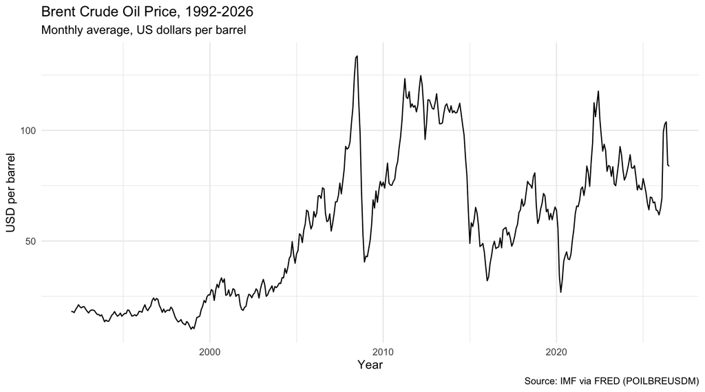

```r
autoplot(oil) +
  labs(
    title = "Brent Crude Oil Price, 1992-2026",
    subtitle = "Monthly average, US dollars per barrel",
    x = "Year", y = "USD per barrel",
    caption = "Source: IMF via FRED (POILBREUSDM)"
  ) +
  theme_minimal()
```

The series shows the major episodes of recent energy market history: the low, stable prices of the 1990s; the sustained climb through the 2000s driven by demand growth; the spike above $130 in mid-2008 followed by collapse during the financial crisis; the plateau above $100 from 2011 to 2014; the collapse of 2014-15; the COVID-19 trough in 2020; and the sharp increase of March 2026.

The 2014-15 collapse is directly relevant to this analysis. As Brent fell from roughly $110 to the mid-$30s, Azerbaijan devalued the manat twice within a single year, in February and December 2015.

## Diagnostics

To begin with, the decomposition shows that oil prices contain almost no seasonal pattern. The seasonal component ranges only from about negative three to positive two dollars, while the series itself ranges from roughly ten to one hundred and thirty dollars. Even though the seasonal component is statistically detectable, it is economically meaningless at this scale. This indicates that seasonal modelling is unnecessary here, unlike series such as electricity demand or tourism where annual cycles are strong.

Furthermore, the Augmented Dickey-Fuller test returns a p-value of 0.3647 for the price series, which means we cannot reject the hypothesis that the series is non-stationary. This is expected, because a price that stood at eighteen dollars in 1992 and one hundred dollars in 2026 has no fixed mean to return to. After taking the first difference, so that the model describes monthly changes rather than price levels, the same test returns a p-value below 0.01. This demonstrates that one order of differencing is sufficient, and it justifies setting d equal to one in the model specification.

Additionally, the autocorrelation function of the differenced series shows a single significant spike at lag one of approximately 0.34, after which the correlations fall inside the confidence bounds. This suggests that this month’s price change carries a small amount of information about next month’s, and essentially none beyond that. In other words, the series behaves close to a random walk, which already implies that forecasting performance will be limited.

## Forecasting the Shock

Automatic model selection by AICc chose an ARIMA(2,1,1) specification. On the training data this model performs reasonably well, with a root mean squared error of 4.60 dollars and a mean absolute percentage error of 6.41 percent. However, these are in-sample statistics, measured on the same data used to fit the model, and they are a poor guide to real forecasting performance.

The out-of-sample results tell a very different story. The model forecast prices of roughly seventy dollars for the months following February 2026, since February closed near sixty-nine dollars and nothing in the price history suggested otherwise. In reality, Brent reached 99.41 dollars in March, 102.81 in April, and 103.84 in May. The test set root mean squared error is 24.29 dollars and the mean absolute percentage error is 22.97 percent, which is roughly five times worse than the training error. This shows how misleading in-sample fit statistics can be when they are reported without out-of-sample validation.

On top of that, the actual values fell outside the model’s 95 percent prediction interval for three consecutive months. This is a more serious failure than simply being wrong. A prediction interval is supposed to express how uncertain the forecast is, and when reality falls outside it, the model was not only mistaken but also overconfident. The reason is that prediction intervals are constructed from historical volatility, so they can only answer the question of how much this series has moved in the past. They cannot account for the closure of a shipping lane.

Furthermore, the naive benchmark produced a test error of 26.96 dollars, only about ten percent worse than the ARIMA model. After four hundred and ten months of data, automatic model selection, and three estimated parameters, the sophisticated model was barely better than assuming that next month equals this month. This demonstrates that the limitation is not in the choice of model but in the nature of the series itself.

## Fiscal Exposure

The forecasting results matter because of who bears the consequences. Oil rents, measured as the value of oil production minus extraction costs, have averaged 25.1 percent of Azerbaijan’s GDP between 2000 and 2021. This is higher than Kazakhstan at 16.1 percent, considerably higher than the Russian Federation at 9.7 percent, and nearly four times higher than Norway at 6.6 percent. Among the countries compared here, only Saudi Arabia is more exposed.

Moreover, the range of Azerbaijan’s exposure is as important as its average. Oil rents reached 39.6 percent of GDP in the peak year and fell to 11.1 percent in the lowest, a spread of more than twenty-eight percentage points. This means that roughly a quarter of the national economy expands and contracts according to a price determined in global markets. On the other hand, Norway produces large quantities of oil but its rents never exceeded 12 percent of GDP, because the surrounding economy is diversified enough to absorb the swings. This illustrates that exposure is a matter of economic structure and policy rather than geology.

To put the two findings together, an error of 22.97 percent applied to a sector averaging 25.1 percent of GDP corresponds to approximately 5.8 percent of GDP. A recession is conventionally defined by a contraction of a few percentage points, so the forecast error I measured maps onto a movement several times that size. This suggests that oil price uncertainty is not a marginal budgeting difficulty for Azerbaijan but a first-order macroeconomic risk.

## Limitations

This analysis has several limitations that should be acknowledged.

To begin with, the test set contains only five observations. Five months is a very short evaluation window, and the error statistics reported here are therefore imprecise. A longer test period would give more reliable estimates, although it would also dilute the specific episode that this analysis is designed to examine.

Furthermore, ARIMA models assume constant variance, and the differenced series clearly violates this assumption. The monthly changes cluster, so that calm periods are followed by calm periods and volatile periods by volatile ones. This pattern is well known in financial series and is normally handled with GARCH models, which explicitly model changing variance. My model does not capture it, which means the prediction intervals are probably too narrow during volatile periods and too wide during calm ones.

Additionally, the calculation linking the forecast error to GDP is illustrative arithmetic rather than a macroeconomic estimate. Oil rents do not translate one for one into national output, the relationship is not linear, and a proper fiscal model would account for production volumes, the sovereign wealth fund, the exchange rate regime, as well as any hedging arrangements. What the calculation does show is the order of magnitude of the problem, not a precise figure.

Finally, this analysis uses Brent crude as a proxy for Azerbaijan’s export price. Azeri Light is priced at a differential to Brent and normally trades at a small premium, so the two move together closely, but they are not identical. Using the actual export price would be preferable if the data were publicly available.

## Conclusion

In conclusion, this analysis finds that oil prices cannot be usefully forecast from their own history. A properly specified ARIMA model, selected automatically and validated out of sample, produced an average error of nearly twenty-three percent over five months and missed the actual outcome by so much that reality fell outside its own confidence interval. The model also failed to substantially outperform a naive forecast that assumed no change at all.

For a country like Azerbaijan, where oil rents have averaged a quarter of GDP, this has a direct policy implication. If the price cannot be predicted, then a budget built on price assumptions will periodically be wrong by a large margin, and in both directions. The 2014 to 2015 collapse produced two currency devaluations, while the 2026 shock produced an unexpected windfall. Therefore the appropriate response is not to invest in better forecasting models but to build fiscal institutions that can absorb shocks, which is the argument for a sovereign wealth fund and for countercyclical budgeting. Norway’s experience suggests this is achievable, since it produces comparable quantities of oil while remaining far less exposed to its price.

Future work could extend this analysis by modelling volatility directly with a GARCH specification, or by testing whether the inclusion of geopolitical risk indices improves forecast performance during shock periods.